# ANLY510 Lab 2

ANLY510 Group 1

2024-03-23

```r
knitr::opts_chunk$set(echo = TRUE)
library(tidyverse)
library(ggplot2)
library(car)
library(ggpubr)
cleanup <- theme(
  panel.grid.major = element_blank(),
  panel.grid.minor = element_blank(),
  panel.background = element_blank(),
  axis.line.x = element_line(color = "black"),
  axis.line.y = element_line(color = "black"),
  legend.key = element_rect(fill = "white"),
  panel.border = element_rect(color = "black", fill = NA),
  text = element_text(size = 11)
)
```

### Research Question

Research Question: Does the type of brewing method affect creme production in Espresso?

H0: There is no significant difference in creme production among the three different Espresso brewing methods. H1: There is a significant difference in creme production among the the three different Espresso brewing methods.

We first looked at the structure of the data and converted the Brew Method to a factor

```r
e <- read.csv("EspressoData.csv")
str(e)
```

```
## 'data.frame':    27 obs. of  2 variables:
##  $ cereme    : num  36.6 39.6 37.7 36 38.5 ...
##  $ brewmethod: int  1 1 1 1 1 1 1 1 1 2 ...
```

```r
e$brewmethod <- as.factor(e$brewmethod)
```

### Levene’s Test

This was used to test the homogeneity of variances amongst the brew method groups

- Null hypothesis - variances across all groups are equal.
- Alternative hypothesis - at least one group has a different variance from the others.

```r
leveneTest(cereme ~ brewmethod, data = e)
```

```
## Levene's Test for Homogeneity of Variance (center = median)
##       Df F value Pr(>F)
## group  2  0.8892 0.4241
##       24
```

p = 0.42. As p>0.05, there was not enough evidence to reject the null so the homogeneity of variances assumption was satisfied, so we proceeded to perform an ANOVA test.

### ANOVA

We performed a one-way ANOVA test using the brew method groups.

- Null Hypothesis - there is no difference among brew method group means
- Alternative Hypothesis - there is a significant difference among brew method group means

```r
e.aov <- aov(cereme ~ brewmethod, data = e)
summary(e.aov)
```

```
##             Df Sum Sq Mean Sq F value  Pr(>F)
## brewmethod   2   4065  2032.6   28.41 4.7e-07 ***
## Residuals   24   1717    71.5
## ---
## Signif. codes:  0 '***' 0.001 '**' 0.01 '*' 0.05 '.' 0.1 ' ' 1
```

According to the anova, p<0.05, so we rejected the null, meaning that there was a significant difference between the brew method group means in this dataset.

### Post-hoc Analysis

```r
e.posthoc<-TukeyHSD(e.aov)
e.posthoc
```

```
##   Tukey multiple comparisons of means
##     95% family-wise confidence level
##
## Fit: aov(formula = cereme ~ brewmethod, data = e)
##
## $brewmethod
##      diff        lwr       upr     p adj
## 2-1  28.9  18.942931  38.85707 0.0000005
## 3-1   7.3  -2.657069  17.25707 0.1811000
## 3-2 -21.6 -31.557069 -11.64293 0.0000419
```

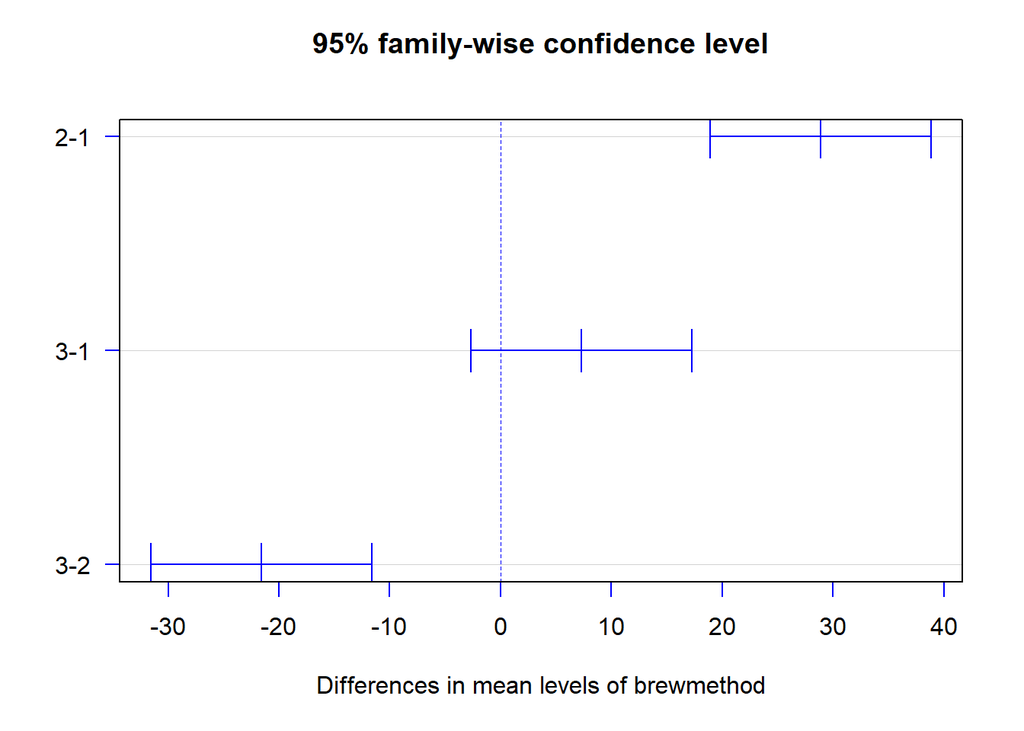

```r
plot(e.posthoc, las = 1, col = "blue")
```

Post-hoc analysis of the 3 Brew method groups revealed that the mean of Brew Method 2 was significantly different from that of Brew Methods 1 and 3, whilst those of Brew Methods 1 and 3 were not significantly different from each other.

### Visualization

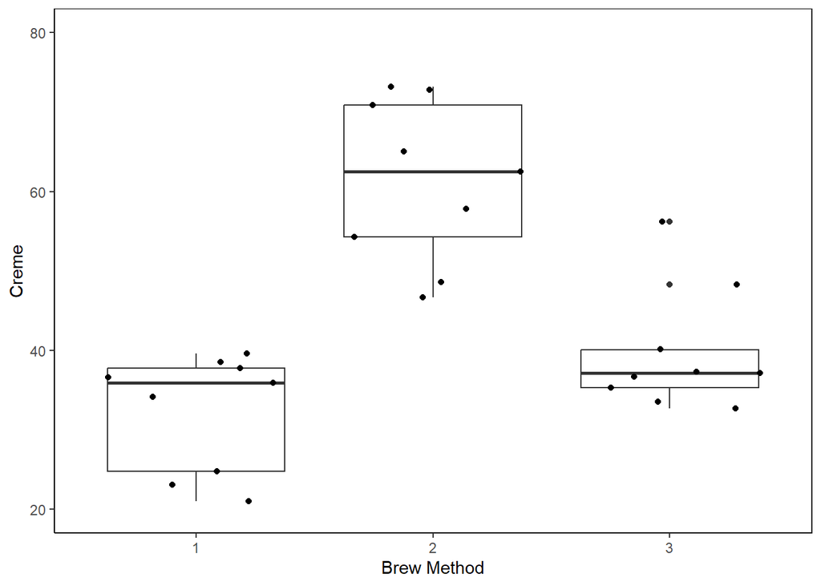

```r
# Box plot
ggplot(e, aes(brewmethod, cereme)) + geom_boxplot() + geom_jitter() + ylim (20,80) + xlab("Brew Method") + ylab("Creme") + cleanup
```

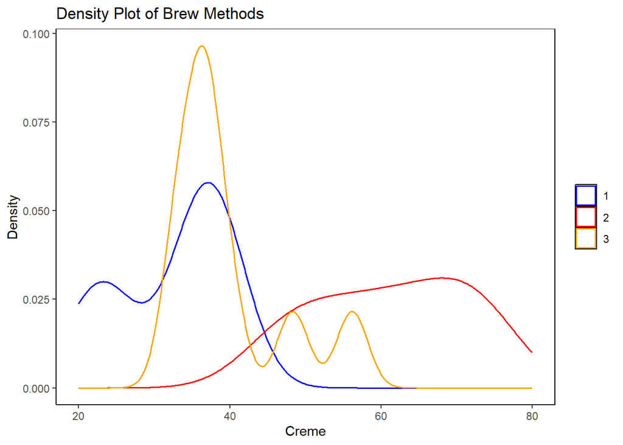

```r
#Density Plot
ggplot(e, aes(x = cereme, color =brewmethod)) + geom_density(size=0.6) + labs(title = "Density Plot of Brew Methods", x = "Creme", y = "Density") + scale_color_manual(values = c("blue", "red","orange")) + xlim(20,80)+  theme(legend.title = element_blank())+ cleanup
```

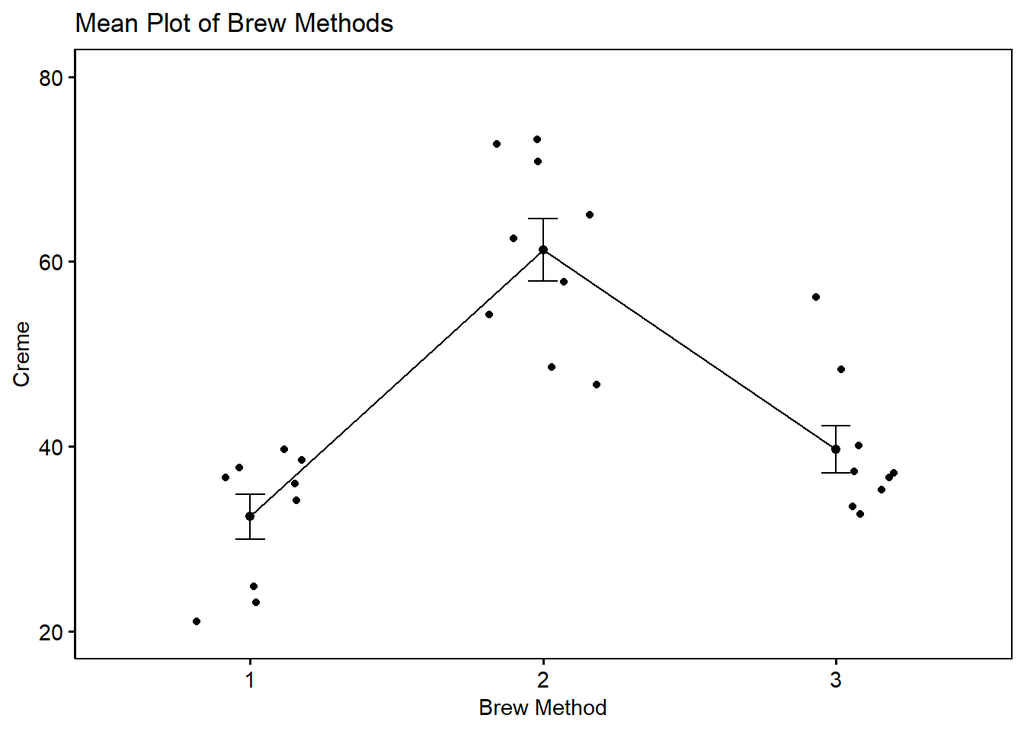

```r
#mean plot
ggline(e, x = "brewmethod", y = "cereme",
       add = c("mean_se", "jitter"),
       ylab = "Creme", xlab = "Brew Method") + ylim(20,80) + labs(title = "Mean Plot of Brew Methods", x = "Brew Method", y = "Creme") + cleanup
```

We then visualized the three brew methods. The brew methods 1 and 3 seemed to have similar distributions and means whilst method 2 seemed to have a significantly higher mean than that of the other 2 groups.

Out of the three methods (one-way Anova, Levene, TukeyHSD post-hoc) used to assess if the type of method affects cream production in Espresso, we found that there were differences in creme production amongst the 3 Espresso brew methods. However, in the post-hoc test, we found there was no significant difference between brew methods 3 and 1. In conclusion, Brew Method 2 produces the most creme on top.